# Regression and model validation

This week I learning quite a bit about data wrangling and performing some basic linear regression

```r
date()
```

```
## [1] "Mon Nov 13 16:07:55 2023"
```

### Creating an enviroment with needed packages

```r
library(tidyverse)
library(GGally)
```

### Reading the data in and checking its structure

```r
students2014 <- read.csv("C:/Users/nicol/Downloads/PHD_302/IODS-project/learning2014.csv")
str(students2014)
```

```
## 'data.frame':    166 obs. of  8 variables:
##  $ X       : int  1 2 3 4 5 6 7 8 9 10 ...
##  $ gender  : chr  "F" "M" "F" "M" ...
##  $ Age     : int  53 55 49 53 49 38 50 37 37 42 ...
##  $ attitude: num  3.7 3.1 2.5 3.5 3.7 3.8 3.5 2.9 3.8 2.1 ...
##  $ deep    : num  3.58 2.92 3.5 3.5 3.67 ...
##  $ stra    : num  3.38 2.75 3.62 3.12 3.62 ...
##  $ surf    : num  2.58 3.17 2.25 2.25 2.83 ...
##  $ Points  : int  25 12 24 10 22 21 21 31 24 26 ...
```

### Creating a graphical overview of the data

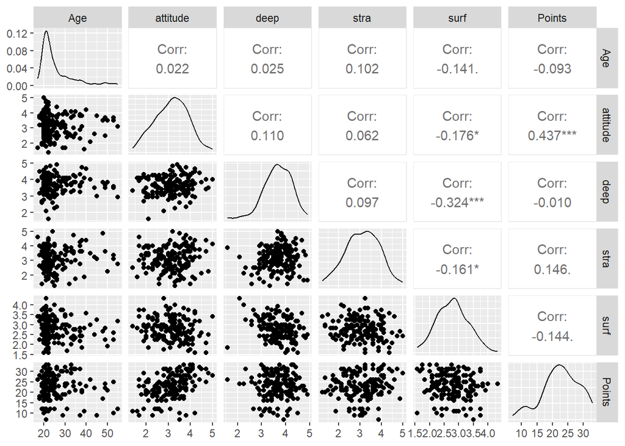

```r
ggpairs(students2014, columns = 3:8)
```

### Selecting variables to test a regression model

```r
first_model <- lm(formula= Points ~ attitude + deep  + Age  + surf + stra, data=students2014)
summary(first_model)
```

```
##
## Call:
## lm(formula = Points ~ attitude + deep + Age + surf + stra, data = students2014)
##
## Residuals:
##      Min       1Q   Median       3Q      Max
## -17.4759  -3.2812   0.3804   3.5381  11.4897
##
## Coefficients:
##             Estimate Std. Error t value Pr(>|t|)
## (Intercept) 18.30059    5.24076   3.492  0.00062 ***
## attitude     3.43200    0.56991   6.022 1.14e-08 ***
## deep        -1.04374    0.78179  -1.335  0.18375
## Age         -0.09650    0.05335  -1.809  0.07234 .
## surf        -1.10529    0.84009  -1.316  0.19016
## stra         0.96551    0.53917   1.791  0.07523 .
## ---
## Signif. codes:  0 '***' 0.001 '**' 0.01 '*' 0.05 '.' 0.1 ' ' 1
##
## Residual standard error: 5.249 on 160 degrees of freedom
## Multiple R-squared:  0.2311, Adjusted R-squared:  0.2071
## F-statistic:  9.62 on 5 and 160 DF,  p-value: 4.803e-08
```

```r
second_model <- lm(formula= Points ~ attitude + deep  + surf + stra, data=students2014)
summary(second_model)
```

```
##
## Call:
## lm(formula = Points ~ attitude + deep + surf + stra, data = students2014)
##
## Residuals:
##      Min       1Q   Median       3Q      Max
## -16.7335  -3.1992   0.7975   3.4002  11.6582
##
## Coefficients:
##             Estimate Std. Error t value Pr(>|t|)
## (Intercept)  15.4000     5.0245   3.065  0.00255 **
## attitude      3.4362     0.5739   5.987 1.34e-08 ***
## deep         -1.0072     0.7870  -1.280  0.20247
## surf         -0.9105     0.8390  -1.085  0.27948
## stra          0.8847     0.5411   1.635  0.10398
## ---
## Signif. codes:  0 '***' 0.001 '**' 0.01 '*' 0.05 '.' 0.1 ' ' 1
##
## Residual standard error: 5.286 on 161 degrees of freedom
## Multiple R-squared:  0.2154, Adjusted R-squared:  0.1959
## F-statistic: 11.05 on 4 and 161 DF,  p-value: 6.057e-08
```

#### Here it seems that the impact of attitude increased when I took out Age, and the Multiple R squared went down. My understanding of statistics is limited, but if the multiple R squared value went down (which ranges between 0 and 1, with 1 being a perfect correlation) the fact that it went down indicates the model fit better with Age included.

### Creating Diagnostic Plots

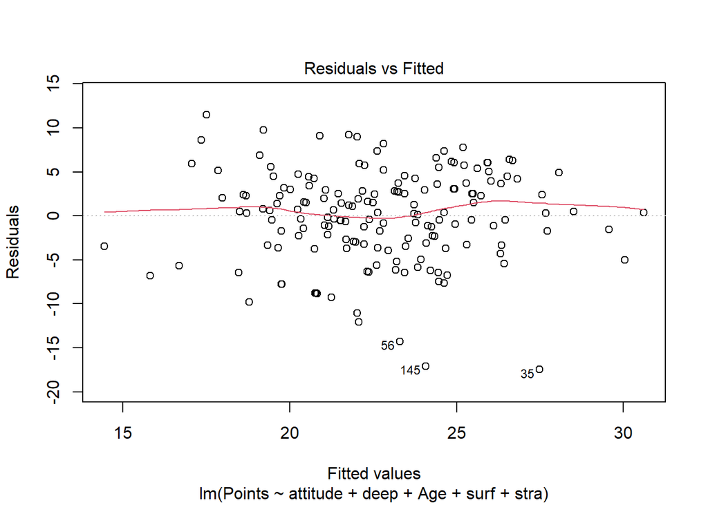

```r
plot(first_model, which = 1, caption = "Residuals vs Fitted")
```

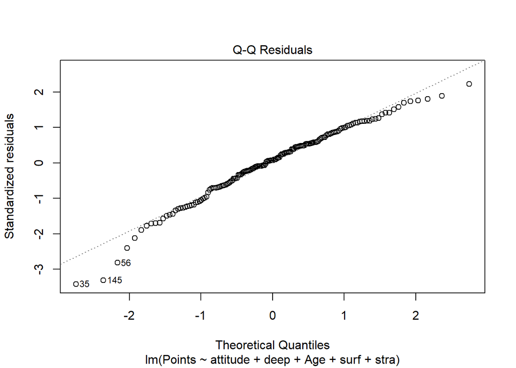

```r
plot(first_model, which = 2)
```

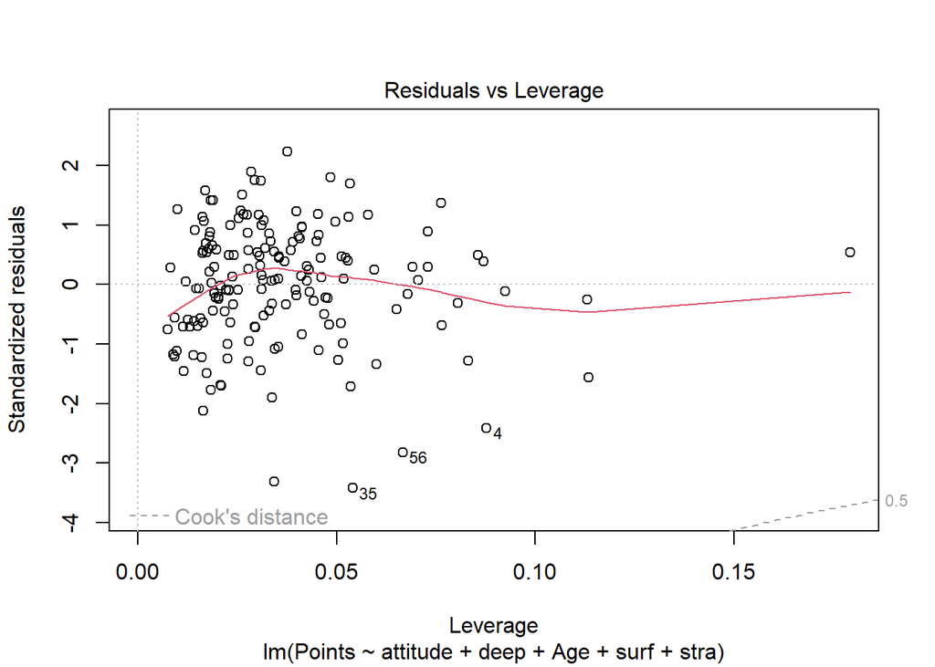

```r
plot(first_model, which = 5)
```

#### *From the online textbook I see that linear regresssion models have 4 assumptions: Linear relationship between predictor variables and outcome, independence of variables, normal distribution of variables and equals variance of variables.

#### **Looking at the Residuals vs Fitted plot it looks like Points are fairly evenly distributed along their axis which indidcates that the models assumptions are valid

#### ***The Q-Q plot also seems to show a normal distriubution in residuals which is also a good check of the model

#### ****The leverage plot seems to show that not many residuals have a large impact on Points. There are a few outliers that might merit removal.